# A3: Incarceration

### Introduction

In the United States, the prison system is one of the most obvious manifestations of racial inequality. Decades of systemic racism, including policies like the war on drugs and disproportionate policing practices, have resulted in an overrepresentation of people of color in prison. Using data from the Vera Institute, this analysis seeks to identify patterns of racial disparities in incarceration. By focusing on variables related to race and incarceration rates, this report aims to highlight how these disparities appear across counties and over time. The variables chosen are important for understanding the scope of racial injustice in the criminal justice system and identifying potential areas for policy reform.

### Summary Information

This analysis is based on a prison dataset containing 153811 records representing diverse incarceration data from 1876 distinct counties across 51 states in the United States. The dataset covers a wide time period, from 1970 to 2018, providing a comprehensive historical perspective on incarceration trends. Examining this extensive data provides valuable insights into the variations and developments in prison populations over the last five decades, allowing for a more nuanced understanding of changes in criminal justice policies and their effects on various communities across the country. This analysis serves as a foundation for further research into specific trends, such as demographic shifts, the impact of legislative changes, and potential areas for policy reform.

### The Dataset

**Who collected the data?**

The data was collected by the Vera Institute of Justice.

**How was the data collected or generated?**

The data was collected from various sources, including the Bureau of Justice Statistics (BJS) data collections such as the Census of Jails (COJ) and the Annual Survey of Jails (ASJ), as well as the BJS National Corrections Reporting Program (NCRP) data collection. These sources provide information on jail and prison populations at the county, jurisdiction, and state levels.

**Why was the data collected?**

The data was collected to analyze and understand trends in incarceration rates, particularly at the county level, in order to inform policy decisions, advance research, and guide changes in justice policy and practice regarding mass incarceration.

**How many observations (rows) are in your data?**

```
## [1] 153811
```

**How many features (columns) are in the data?**

```
## [1] 36
```

**What, if any, ethical questions or questions of power do you need to consider when working with this data?**

When working with this data, ethical questions may arise concerning issues such as data privacy, fairness in justice systems, and the impact of incarceration on marginalized communities. Additionally, questions of power may arise regarding the representation and interpretation of the data, as well as the influence of various stakeholders in justice policy and practice.

**What are possible limitations or problems with this data?**

Several limitations may have an impact on this data’s utility and accuracy. Firstly, relying on official sources such as the COJ and ASJ may introduce biases depending on what these institutions choose to report or emphasize. The COJ’s periodic nature, and the ASJ’s partial coverage, may result in data gaps or outdated information. Furthermore, changes in data collection methods over time may affect consistency and comparability across different data sets or time periods. Also, the data’s focus on incarceration implies that it involves individuals and systems with significant power disparities. This includes how the justice system interacts with marginalized communities, particularly racial minorities, who are disproportionately affected by incarceration policies. Researchers and policymakers must consider these dynamics in order to avoid misinterpretations that could perpetuate harm or inequality. Furthermore, while the dataset is comprehensive, it may overlook nuanced local practices or unreported metrics that could provide more insight into the justice system’s operations and impacts. This may limit our ability to fully understand or address the root causes of disparities in incarceration rates.

### Trends Over Time Chart

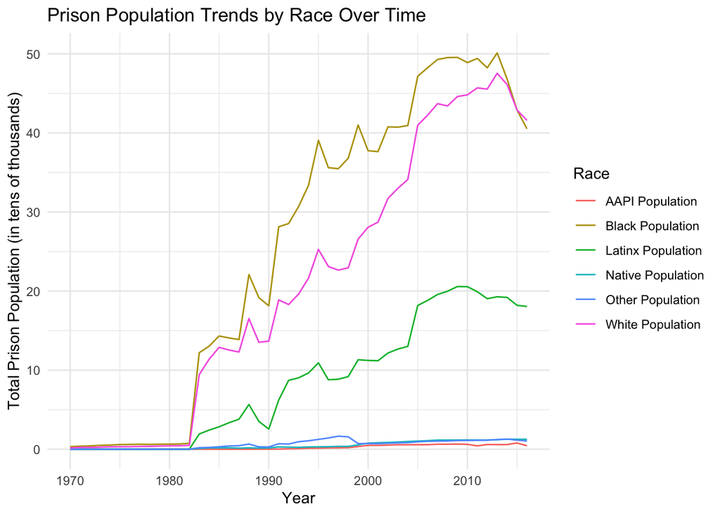

### Variable Comparison Chart

This grouped bar chart compares the prison population rates for Black and White populations over time. The chart aims to highlight the disparities in incarceration rates between these two racial groups and track how they have changed between 1990 and 2016. The chart shows a consistent and significant disparity in prison population rates for Black and White populations. Historically, Black people have had a significantly higher prison population rate than White people. The chart also depicts trends over time, such as peaks and declines in incarceration rates, which could be attributed to a variety of sociopolitical factors and changes in law enforcement practices or policies.

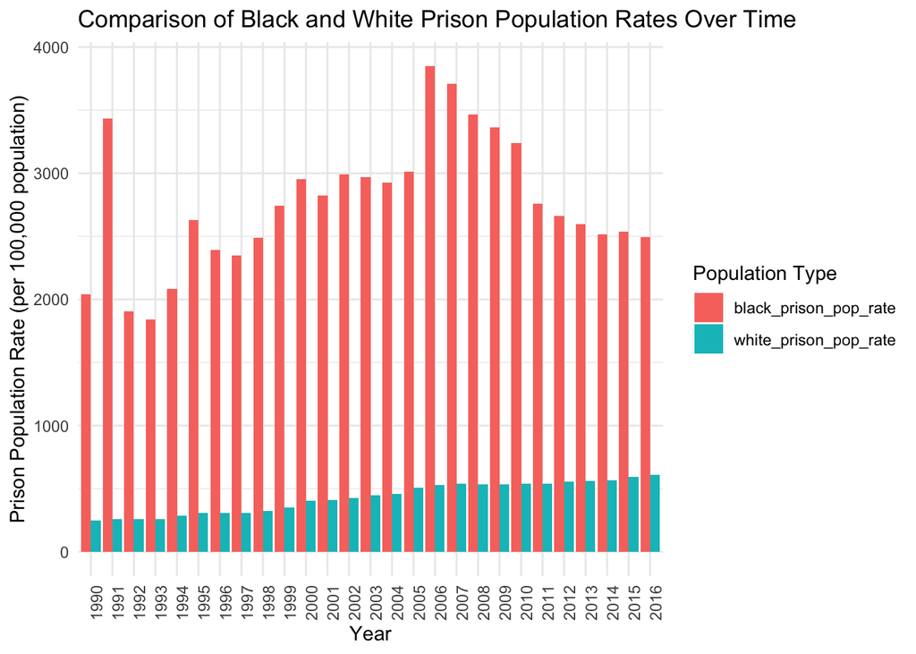

### Map

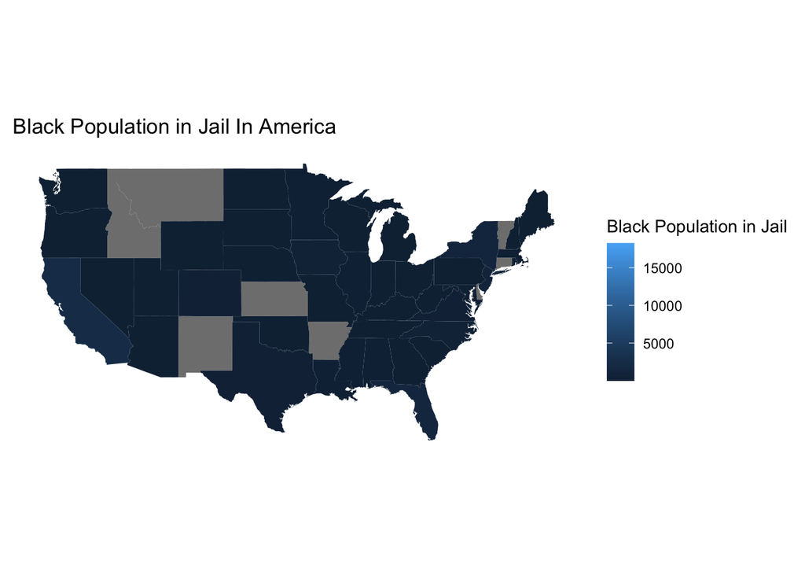